# LLMs for Fun and Profit

Frank DiTraglia

## Link to these slides

[figure not shown]

https://ditraglia.com/llms-for-fun-and-profit

## LLMs are the best RA you’ve ever had

- Dramatically faster
- Dramatically cheaper
- 80th percentile (my opinion) in general aptitude
- 99th percentile (my opinion) in coding

**If you’re not using LLMs on a daily basis, you’re missing out.**

## Which LLMs to use?

I subscribe to all three “frontier” models:

- I use [Claude](https://claude.ai) and [ChatGPT](https://chatgpt.com) daily; occasionally [Gemini](https://gemini.google.com)
- Claude is my favorite, esp. for coding / language tasks
- ChatGPT has more bells and whistles
  - Generate images
  - `o1` for “deep thinking” (useful for math)
  - search the web
- Gemini has never given me good results but I keep trying

## Reverse-compile a LaTeX Document

- This tutorial sheet is full of typos; but I don’t have the TeX!
- Two options
  1. Copy-and-paste the text of the .pdf into an LLM or
  2. Upload the .pdf itself
- Provide a prompt like this:

> Here is text that I’ve copied and pasted from a .pdf document generated using LaTeX. Please give me the undelyring TeX code needed to generate this document.

## List of things

1. Reverse compile a LaTeX document.
2. Help you make a TikZ figure (flowchart)
3. Get help using Hugo / the command line / git etc. (feed in error messages)
4. Convert whiteboard notes into LaTeX
5. Make clipart for your teaching slides
6. Help you write tweets that stay in the word limit and are idiomatic
7. Help you write grants: read through a long notes document, read through grant requirements, and suggest things to talk about
8. Practice giving an Oxford undergraduate interview
9. Get feedback on your teaching materials
10. Create new teaching examples (esp coding examples)
11. An improved rubber duckie: talk to it about something you’re trying to understand better. Optionally, feed in a paper you don’t understand or take a picture of a paragraph you don’t understand.
12. Get legal advice / ask for help drafting formal legal documents (e.g. formal complaint): seriously it’s pretty good. Ask ChatGPT to *point you to particular precedents or statutes that are relevant*. Then look these up on govt websites and other sources.
13. Get help learning a new language or improving one you already know.
14. Get help setting boundaries with students, giving harsh feedback, etc. (Check email for tone, write a pitch perfect “you’re in trouble now” email for an Oxford student, including welfare support etc.)
15. Help writing a blog post: get feedback on organization and content.
16. Check your algebra / help you with derivations: o1 is best for this in my experience although Claude is also very good despite lacking TeX display capability.

## While I have your attention…

- LLMs lower cost of learning *other* productivity tools
- Low-hanging fruit:
  1. Learn how to touch type fast!
  2. Version control with git / github
  3. The LaTeX exam class
  4. Quarto / Markdown

## Is your workflow stuck in the 1990s?

- `paper_restud_final_v23_withedits_revised.tex`
- “Why have all the numbers in table 2 changed?”
- “I can’t find the version we submitted to Econometrica!”
- “I’m working in Dropbox now: stay out of the paper folder!”
- “Oops: I gave the wrong exam to the MPhil students!”

## Version Control: git / github

- Keep past versions of your work without the clutter
- Collaborate with others without the chaos
- Track changes to your work over time
- Share your code / results with the world
- Let’s Git started!
  - [Happy Git and Github](https://happygitwithr.com/)
  - Repos for [these slides](https://github.com/fditraglia/llms-for-fun-and-profit/), [my website](https://github.com/fditraglia/fditraglia.github.io), [a paper](https://github.com/fditraglia/binary-regressor)

## The LaTeX Exam Class

I thought every one already used this; but apparently not…

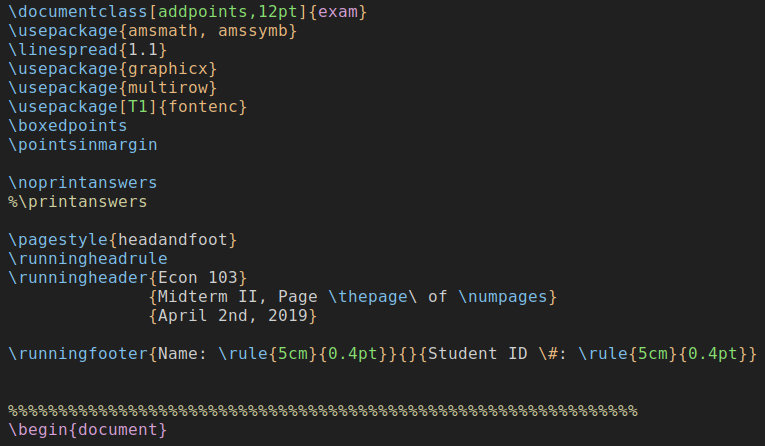

Choose whether to show solutions

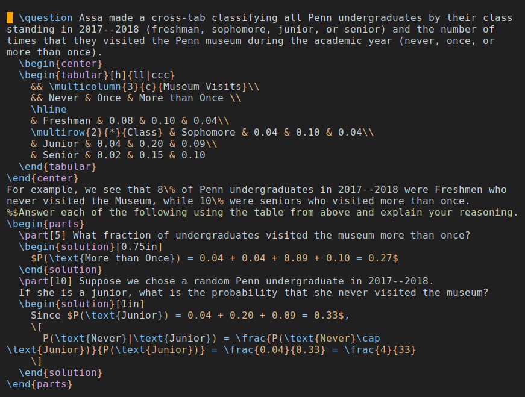

Single TeX file file for questions and solutions

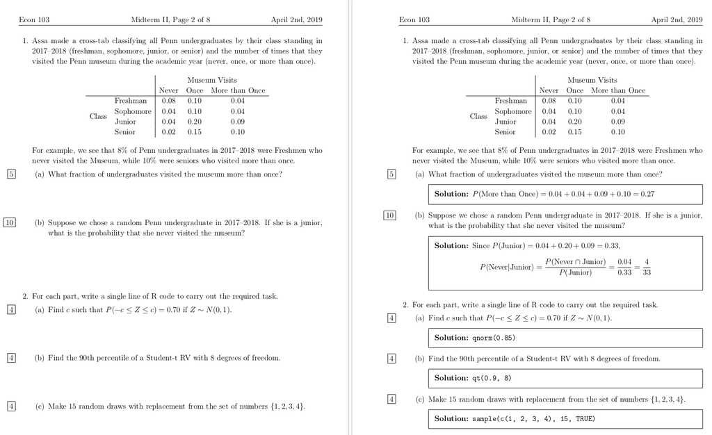

Two different pdfs from the same TeX file

## Quarto / Markdown

- This document was made using [Quarto](https://quarto.org/)
- Weave together content & code into a finished document
- Many output formats: slides, papers, websites, books, etc.
- Even Microsoft Word / Powerpoint!
  - <crosses self, sprays holy water>
- Simple syntax, easy to learn: based on [Markdown](https://www.markdownguide.org/)